# **Regression Project: Boston House Price Prediction**

# **Marks: 60**

Welcome to the project on regression. We will use the **Boston house price dataset** for this project.

## **Objective**

The problem at hand is to **predict the housing prices of a town or a suburb based on the features of the locality provided to us**. In the process, we need to **identify the most important features affecting the price of the house**. We need to employ techniques of data preprocessing and build a linear regression model that predicts the prices for the unseen data.

## **Dataset**

Each record in the database describes a house in Boston suburb or town. The data was drawn from the Boston Standard Metropolitan Statistical Area (SMSA) in 1970. Detailed attribute information can be found below:

Attribute Information:

- **CRIM:** Per capita crime rate by town
- **ZN:** Proportion of residential land zoned for lots over 25,000 sq.ft.
- **INDUS:** Proportion of non-retail business acres per town
- **CHAS:** Charles River dummy variable (= 1 if tract bounds river; 0 otherwise)
- **NOX:** Nitric Oxide concentration (parts per 10 million)
- **RM:** The average number of rooms per dwelling
- **AGE:** Proportion of owner-occupied units built before 1940
- **DIS:** Weighted distances to five Boston employment centers
- **RAD:** Index of accessibility to radial highways
- **TAX:** Full-value property-tax rate per 10,000 dollars
- **PTRATIO:** Pupil-teacher ratio by town
- **LSTAT:** % lower status of the population
- **MEDV:** Median value of owner-occupied homes in 1000 dollars

## **Importing the necessary libraries**

```python
# Importing all libraries that might be necessary for analyzing data set
import pandas as pd
import numpy as np
import matplotlib.pyplot as plt
import seaborn as sns
from statsmodels.graphics.gofplots import ProbPlot
from statsmodels.formula.api import ols
import statsmodels.api as sm
from sklearn.linear_model import LinearRegression
from sklearn.model_selection import train_test_split
from sklearn.preprocessing import MinMaxScaler
from statsmodels.stats.outliers_influence import variance_inflation_factor
```

### Loading the dataset

```python
df = pd.read_csv('Boston.csv')
```

## Data Overview

- Observations
- Sanity checks

```python
df.head()
```

|  | CRIM | ZN | INDUS | CHAS | NOX | RM | AGE | DIS | RAD | TAX | PTRATIO | LSTAT | MEDV |
| --- | --- | --- | --- | --- | --- | --- | --- | --- | --- | --- | --- | --- | --- |
| 0 | 0.00632 | 18.0 | 2.31 | 0 | 0.538 | 6.575 | 65.2 | 4.0900 | 1 | 296 | 15.3 | 4.98 | 24.0 |
| 1 | 0.02731 | 0.0 | 7.07 | 0 | 0.469 | 6.421 | 78.9 | 4.9671 | 2 | 242 | 17.8 | 9.14 | 21.6 |
| 2 | 0.02729 | 0.0 | 7.07 | 0 | 0.469 | 7.185 | 61.1 | 4.9671 | 2 | 242 | 17.8 | 4.03 | 34.7 |
| 3 | 0.03237 | 0.0 | 2.18 | 0 | 0.458 | 6.998 | 45.8 | 6.0622 | 3 | 222 | 18.7 | 2.94 | 33.4 |
| 4 | 0.06905 | 0.0 | 2.18 | 0 | 0.458 | 7.147 | 54.2 | 6.0622 | 3 | 222 | 18.7 | 5.33 | 36.2 |

```python
df.tail()
```

|  | CRIM | ZN | INDUS | CHAS | NOX | RM | AGE | DIS | RAD | TAX | PTRATIO | LSTAT | MEDV |
| --- | --- | --- | --- | --- | --- | --- | --- | --- | --- | --- | --- | --- | --- |
| 501 | 0.06263 | 0.0 | 11.93 | 0 | 0.573 | 6.593 | 69.1 | 2.4786 | 1 | 273 | 21.0 | 9.67 | 22.4 |
| 502 | 0.04527 | 0.0 | 11.93 | 0 | 0.573 | 6.120 | 76.7 | 2.2875 | 1 | 273 | 21.0 | 9.08 | 20.6 |
| 503 | 0.06076 | 0.0 | 11.93 | 0 | 0.573 | 6.976 | 91.0 | 2.1675 | 1 | 273 | 21.0 | 5.64 | 23.9 |
| 504 | 0.10959 | 0.0 | 11.93 | 0 | 0.573 | 6.794 | 89.3 | 2.3889 | 1 | 273 | 21.0 | 6.48 | 22.0 |
| 505 | 0.04741 | 0.0 | 11.93 | 0 | 0.573 | 6.030 | 80.8 | 2.5050 | 1 | 273 | 21.0 | 7.88 | 11.9 |

```python
print("Number of rows: ", df.shape[0])
print("Number of columns: ", df.shape[1])
```

```
Number of rows:  506
Number of columns:  13
```

```python
df.info()
```

```
<class 'pandas.core.frame.DataFrame'>
RangeIndex: 506 entries, 0 to 505
Data columns (total 13 columns):
 #   Column   Non-Null Count  Dtype
---  ------   --------------  -----
 0   CRIM     506 non-null    float64
 1   ZN       506 non-null    float64
 2   INDUS    506 non-null    float64
 3   CHAS     506 non-null    int64
 4   NOX      506 non-null    float64
 5   RM       506 non-null    float64
 6   AGE      506 non-null    float64
 7   DIS      506 non-null    float64
 8   RAD      506 non-null    int64
 9   TAX      506 non-null    int64
 10  PTRATIO  506 non-null    float64
 11  LSTAT    506 non-null    float64
 12  MEDV     506 non-null    float64
dtypes: float64(10), int64(3)
memory usage: 51.5 KB
```

```python
df.duplicated().sum()
```

```
0
```

```python
df.describe()
```

|  | CRIM | ZN | INDUS | CHAS | NOX | RM | AGE | DIS | RAD | TAX | PTRATIO | LSTAT | MEDV |
| --- | --- | --- | --- | --- | --- | --- | --- | --- | --- | --- | --- | --- | --- |
| count | 506.000000 | 506.000000 | 506.000000 | 506.000000 | 506.000000 | 506.000000 | 506.000000 | 506.000000 | 506.000000 | 506.000000 | 506.000000 | 506.000000 | 506.000000 |
| mean | 3.613524 | 11.363636 | 11.136779 | 0.069170 | 0.554695 | 6.284634 | 68.574901 | 3.795043 | 9.549407 | 408.237154 | 18.455534 | 12.653063 | 22.532806 |
| std | 8.601545 | 23.322453 | 6.860353 | 0.253994 | 0.115878 | 0.702617 | 28.148861 | 2.105710 | 8.707259 | 168.537116 | 2.164946 | 7.141062 | 9.197104 |
| min | 0.006320 | 0.000000 | 0.460000 | 0.000000 | 0.385000 | 3.561000 | 2.900000 | 1.129600 | 1.000000 | 187.000000 | 12.600000 | 1.730000 | 5.000000 |
| 25% | 0.082045 | 0.000000 | 5.190000 | 0.000000 | 0.449000 | 5.885500 | 45.025000 | 2.100175 | 4.000000 | 279.000000 | 17.400000 | 6.950000 | 17.025000 |
| 50% | 0.256510 | 0.000000 | 9.690000 | 0.000000 | 0.538000 | 6.208500 | 77.500000 | 3.207450 | 5.000000 | 330.000000 | 19.050000 | 11.360000 | 21.200000 |
| 75% | 3.677083 | 12.500000 | 18.100000 | 0.000000 | 0.624000 | 6.623500 | 94.075000 | 5.188425 | 24.000000 | 666.000000 | 20.200000 | 16.955000 | 25.000000 |
| max | 88.976200 | 100.000000 | 27.740000 | 1.000000 | 0.871000 | 8.780000 | 100.000000 | 12.126500 | 24.000000 | 711.000000 | 22.000000 | 37.970000 | 50.000000 |

```python
df.isna().sum()
```

|  | 0 |
| --- | --- |
| CRIM | 0 |
| ZN | 0 |
| INDUS | 0 |
| CHAS | 0 |
| NOX | 0 |
| RM | 0 |
| AGE | 0 |
| DIS | 0 |
| RAD | 0 |
| TAX | 0 |
| PTRATIO | 0 |
| LSTAT | 0 |
| MEDV | 0 |

**dtype:** int64

### **Observations**

- All of the columns (total of 13) are numeric data types, with 10 of them being floats and 3 being ints
- There is a total of 506 rows (a.k.a. values) for each row, which all are non-null (no missing values) or non-applicable cells

## Exploratory Data Analysis (EDA)

- EDA is an important part of any project involving data.
- It is important to investigate and understand the data better before building a model with it.
- A few questions have been mentioned below which will help you approach the analysis in the right manner and generate insights from the data.
- A thorough analysis of the data, in addition to the questions mentioned below, should be done.

**Questions:**

1. What does the distribution of 'MEDV' look like?
2. What can we infer form the correlation heatmap? Is there correlation between the dependent and independent variables?
3. What are all the inferences that can be found by doing univariate analysis for different variables?
4. Do bivariate analysis to visualize the relationship between the features having significant correlations (>= 0.7 or <= -0.7)

**Answers:**

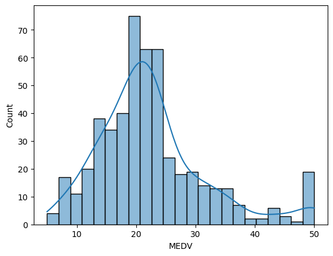

```python
sns.histplot(data = df, x = 'MEDV', kde = True)
```

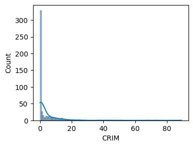

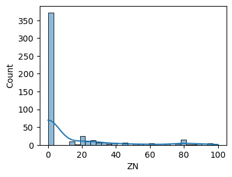

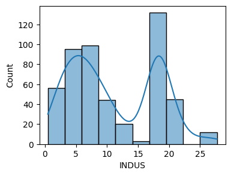

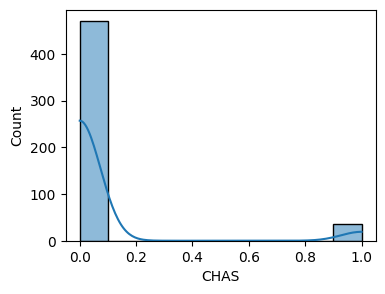

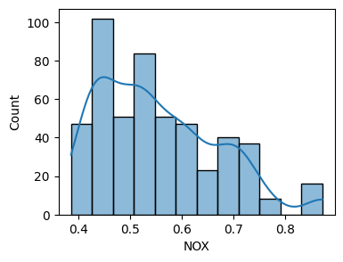

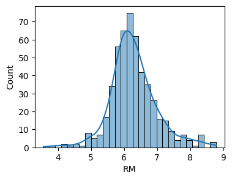

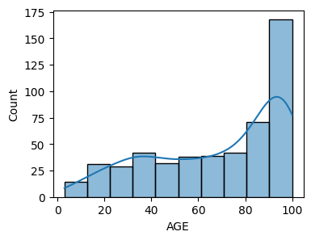

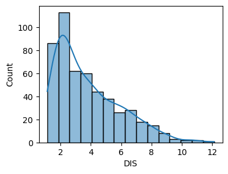

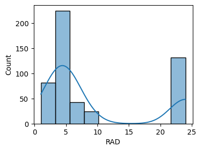

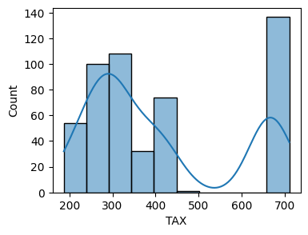

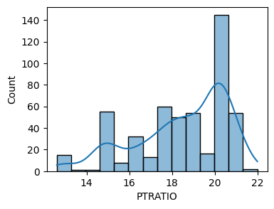

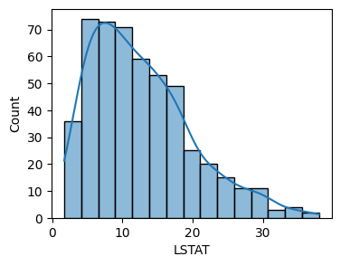

[1 more figures not shown]

```python
for column in df.columns:
  plt.figure(figsize = (4, 3))
  sns.histplot(data = df, x = column, kde = True)
  plt.show()
```

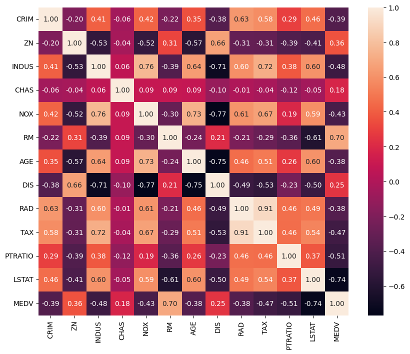

```python
plt.figure(figsize = (10, 8))
sns.heatmap(df.corr(), annot = True, fmt = '.2f')
```

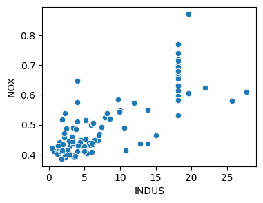

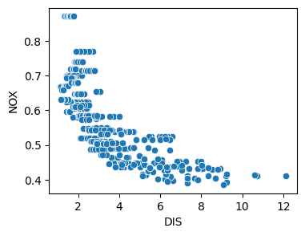

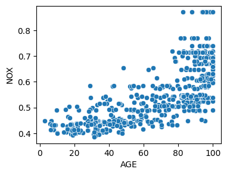

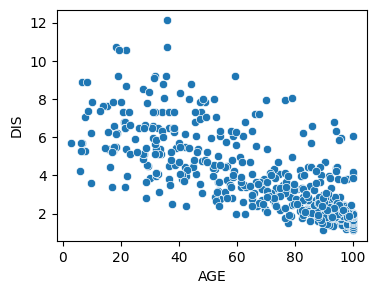

```python
plt.figure(figsize = (4, 3))
sns.scatterplot(x = 'INDUS', y = 'NOX', data = df)
plt.show()

plt.figure(figsize = (4, 3))
sns.scatterplot(x = 'DIS', y = 'NOX', data = df)
plt.show()

plt.figure(figsize = (4, 3))
sns.scatterplot(x = 'AGE', y = 'NOX', data = df)
plt.show()

plt.figure(figsize = (4, 3))
sns.scatterplot(x = 'AGE', y = 'DIS', data = df)
plt.show()
```

## Data Preprocessing

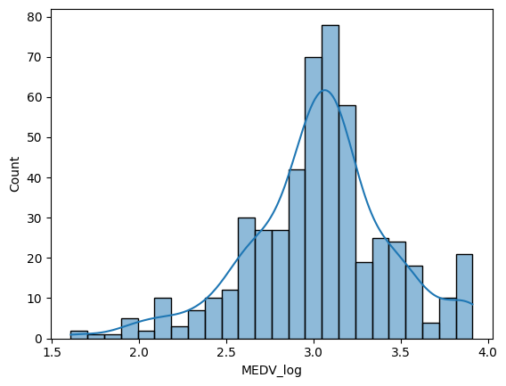

```python
df['MEDV_log'] = np.log(df['MEDV'])
sns.histplot(data = df, x = 'MEDV_log', kde = True)
```

## Model Building - Linear Regression

```python
dependent = df['MEDV_log']
independent = df.drop(['MEDV', 'MEDV_log'], axis = 1)
independent = sm.add_constant(independent)

independent_train, independent_test, dependent_train, dependent_test = train_test_split(independent, dependent, test_size = 0.2, random_state = 42)
```

```python
model_proto = sm.OLS(dependent_train, independent_train).fit()
model_proto.summary()
```

OLS Regression Results

| Dep. Variable: | MEDV_log | R-squared: | 0.783 |
| --- | --- | --- | --- |
| Model: | OLS | Adj. R-squared: | 0.777 |
| Method: | Least Squares | F-statistic: | 117.7 |
| Date: | Fri, 18 Oct 2024 | Prob (F-statistic): | 1.24e-121 |
| Time: | 15:36:33 | Log-Likelihood: | 94.742 |
| No. Observations: | 404 | AIC: | -163.5 |
| Df Residuals: | 391 | BIC: | -111.5 |
| Df Model: | 12 |  |  |
| Covariance Type: | nonrobust |  |  |

|  | coef | std err | t | P>\|t\| | [0.025 | 0.975] |
| --- | --- | --- | --- | --- | --- | --- |
| const | 4.1563 | 0.224 | 18.586 | 0.000 | 3.717 | 4.596 |
| CRIM | -0.0103 | 0.001 | -7.271 | 0.000 | -0.013 | -0.008 |
| ZN | 0.0008 | 0.001 | 1.200 | 0.231 | -0.001 | 0.002 |
| INDUS | 0.0023 | 0.003 | 0.849 | 0.396 | -0.003 | 0.008 |
| CHAS | 0.1086 | 0.039 | 2.773 | 0.006 | 0.032 | 0.186 |
| NOX | -0.7733 | 0.174 | -4.449 | 0.000 | -1.115 | -0.432 |
| RM | 0.1038 | 0.019 | 5.472 | 0.000 | 0.066 | 0.141 |
| AGE | -1.2e-05 | 0.001 | -0.020 | 0.984 | -0.001 | 0.001 |
| DIS | -0.0498 | 0.009 | -5.362 | 0.000 | -0.068 | -0.032 |
| RAD | 0.0101 | 0.003 | 3.239 | 0.001 | 0.004 | 0.016 |
| TAX | -0.0005 | 0.000 | -3.066 | 0.002 | -0.001 | -0.000 |
| PTRATIO | -0.0360 | 0.006 | -6.092 | 0.000 | -0.048 | -0.024 |
| LSTAT | -0.0297 | 0.002 | -13.081 | 0.000 | -0.034 | -0.025 |

| Omnibus: | 32.780 | Durbin-Watson: | 2.165 |
| --- | --- | --- | --- |
| Prob(Omnibus): | 0.000 | Jarque-Bera (JB): | 97.031 |
| Skew: | 0.321 | Prob(JB): | 8.51e-22 |
| Kurtosis: | 5.314 | Cond. No. | 1.15e+04 |

Notes:  
[1] Standard Errors assume that the covariance matrix of the errors is correctly specified.  
[2] The condition number is large, 1.15e+04. This might indicate that there are  
strong multicollinearity or other numerical problems.

## Model Performance Check

```python
#vif function
def vif_func(train):
    vif = pd.DataFrame()
    vif["feature"] = train.columns

    vif["VIF"] = [variance_inflation_factor(train.values, i) for i in range(len(train.columns))]
    return vif

print(vif_func(independent_train))
```

```
    feature         VIF
0     const  533.795744
1      CRIM    1.696872
2        ZN    2.465370
3     INDUS    3.866578
4      CHAS    1.091813
5       NOX    4.455348
6        RM    1.927214
7       AGE    2.984020
8       DIS    4.167114
9       RAD    7.619827
10      TAX    8.932003
11  PTRATIO    1.849262
12    LSTAT    2.773390
```

```python
from sklearn.metrics import mean_squared_error, mean_absolute_error, r2_score

predictions = model_proto.predict(independent_test)

r_squared = r2_score(dependent_test, predictions)
rmse = mean_squared_error(dependent_test, predictions, squared=False)
mae = mean_absolute_error(dependent_test, predictions)
mape = np.mean(np.abs((dependent_test - predictions) / dependent_test)) * 100

print(f"R-squared: {r_squared}")
print(f"RMSE: {rmse}")
print(f"MAE: {mae}")
print(f"MAPE: {mape}")
```

```
R-squared: 0.7723034328648217
RMSE: 0.18839908161863014
MAE: 0.12610456134354409
MAPE: 4.457374138666623
```

```python
independent_train = independent_train.drop(['TAX'], axis = 1)
print(vif_func(independent_train))
```

```
    feature         VIF
0     const  525.982934
1      CRIM    1.696795
2        ZN    2.272069
3     INDUS    3.265830
4      CHAS    1.079355
5       NOX    4.410422
6        RM    1.915213
7       AGE    2.983922
8       DIS    4.159586
9       RAD    2.777426
10  PTRATIO    1.837903
11    LSTAT    2.771986
```

```python
model = sm.OLS(dependent_train, independent_train).fit()
print(model.summary())
```

```
                            OLS Regression Results
==============================================================================
Dep. Variable:               MEDV_log   R-squared:                       0.778
Model:                            OLS   Adj. R-squared:                  0.772
Method:                 Least Squares   F-statistic:                     124.9
Date:                Fri, 18 Oct 2024   Prob (F-statistic):          1.09e-120
Time:                        15:36:40   Log-Likelihood:                 89.942
No. Observations:                 404   AIC:                            -155.9
Df Residuals:                     392   BIC:                            -107.9
Df Model:                          11
Covariance Type:            nonrobust
==============================================================================
                 coef    std err          t      P>|t|      [0.025      0.975]
------------------------------------------------------------------------------
const          4.0734      0.224     18.157      0.000       3.632       4.514
CRIM          -0.0103      0.001     -7.174      0.000      -0.013      -0.007
ZN             0.0002      0.001      0.352      0.725      -0.001       0.001
INDUS         -0.0010      0.003     -0.387      0.699      -0.006       0.004
CHAS           0.1215      0.039      3.085      0.002       0.044       0.199
NOX           -0.8268      0.175     -4.731      0.000      -1.170      -0.483
RM             0.1084      0.019      5.672      0.000       0.071       0.146
AGE        -1.484e-06      0.001     -0.002      0.998      -0.001       0.001
DIS           -0.0486      0.009     -5.181      0.000      -0.067      -0.030
RAD            0.0025      0.002      1.302      0.194      -0.001       0.006
PTRATIO       -0.0374      0.006     -6.285      0.000      -0.049      -0.026
LSTAT         -0.0295      0.002    -12.878      0.000      -0.034      -0.025
==============================================================================
Omnibus:                       30.139   Durbin-Watson:                   2.188
Prob(Omnibus):                  0.000   Jarque-Bera (JB):               85.474
Skew:                           0.295   Prob(JB):                     2.75e-19
Kurtosis:                       5.174   Cond. No.                     2.06e+03
==============================================================================

Notes:
[1] Standard Errors assume that the covariance matrix of the errors is correctly specified.
[2] The condition number is large, 2.06e+03. This might indicate that there are
strong multicollinearity or other numerical problems.
```

```python
predictions = model.predict(independent_test.drop(['TAX'], axis = 1))

r_squared = r2_score(dependent_test, predictions)
rmse = mean_squared_error(dependent_test, predictions, squared=False)
mae = mean_absolute_error(dependent_test, predictions)
mape = np.mean(np.abs((dependent_test - predictions) / dependent_test)) * 100

print(f"R-squared: {r_squared}")
print(f"RMSE: {rmse}")
print(f"MAE: {mae}")
print(f"MAPE: {mape}")
```

```
R-squared: 0.7533039021473575
RMSE: 0.19610184510592268
MAE: 0.1313702887781432
MAPE: 4.655909830730988
```

```python
independent_train = independent_train.drop(['NOX'], axis = 1)
print(vif_func(independent_train))
```

```
    feature         VIF
0     const  360.929101
1      CRIM    1.690366
2        ZN    2.267807
3     INDUS    2.879703
4      CHAS    1.074377
5        RM    1.902724
6       AGE    2.815771
7       DIS    3.847352
8       RAD    2.476944
9   PTRATIO    1.621707
10    LSTAT    2.728147
```

```python
model = sm.OLS(dependent_train, independent_train).fit()
print(model.summary())
```

```
                            OLS Regression Results
==============================================================================
Dep. Variable:               MEDV_log   R-squared:                       0.765
Model:                            OLS   Adj. R-squared:                  0.759
Method:                 Least Squares   F-statistic:                     128.1
Date:                Fri, 18 Oct 2024   Prob (F-statistic):          4.64e-117
Time:                        15:36:45   Log-Likelihood:                 78.724
No. Observations:                 404   AIC:                            -135.4
Df Residuals:                     393   BIC:                            -91.43
Df Model:                          10
Covariance Type:            nonrobust
==============================================================================
                 coef    std err          t      P>|t|      [0.025      0.975]
------------------------------------------------------------------------------
const          3.4788      0.191     18.230      0.000       3.104       3.854
CRIM          -0.0099      0.001     -6.715      0.000      -0.013      -0.007
ZN             0.0004      0.001      0.543      0.588      -0.001       0.002
INDUS         -0.0052      0.002     -2.089      0.037      -0.010      -0.000
CHAS           0.1088      0.040      2.698      0.007       0.030       0.188
RM             0.1157      0.020      5.915      0.000       0.077       0.154
AGE           -0.0007      0.001     -1.128      0.260      -0.002       0.001
DIS           -0.0364      0.009     -3.934      0.000      -0.055      -0.018
RAD           -0.0005      0.002     -0.263      0.793      -0.004       0.003
PTRATIO       -0.0278      0.006     -4.833      0.000      -0.039      -0.016
LSTAT         -0.0309      0.002    -13.226      0.000      -0.035      -0.026
==============================================================================
Omnibus:                       36.977   Durbin-Watson:                   2.124
Prob(Omnibus):                  0.000   Jarque-Bera (JB):              114.870
Skew:                           0.366   Prob(JB):                     1.14e-25
Kurtosis:                       5.508   Cond. No.                     1.51e+03
==============================================================================

Notes:
[1] Standard Errors assume that the covariance matrix of the errors is correctly specified.
[2] The condition number is large, 1.51e+03. This might indicate that there are
strong multicollinearity or other numerical problems.
```

```python
predictions = model.predict(independent_test.drop(['TAX', 'NOX'], axis = 1))

r_squared = r2_score(dependent_test, predictions)
rmse = mean_squared_error(dependent_test, predictions, squared=False)
mae = mean_absolute_error(dependent_test, predictions)
mape = np.mean(np.abs((dependent_test - predictions) / dependent_test)) * 100

print(f"R-squared: {r_squared}")
print(f"RMSE: {rmse}")
print(f"MAE: {mae}")
print(f"MAPE: {mape}")
```

```
R-squared: 0.7333624506634199
RMSE: 0.20387369514944495
MAE: 0.1335296637951329
MAPE: 4.736804929065331
```

```python
from sklearn.model_selection import cross_val_score

# Linear Regression model
lin_model = LinearRegression()

# Cross Validation with r-squared and RMSE
scoreR2 = cross_val_score(lin_model, independent_train, dependent_train, cv=5, scoring = 'r2')
scoreRMSE = cross_val_score(lin_model, independent_train, dependent_train, cv=5, scoring = 'neg_mean_squared_error')

print("Cross-validation R-squared:", scoreR2)
print("Cross-validation RMSE:", scoreRMSE)

# Calculate and print the average R-squared score
average_r2 = scoreR2.mean()
average_rmse = scoreRMSE.mean()
print("Average cross-validation R-squared:", average_r2)
print("Average cross-validation RMSE:", average_rmse)
```

```
Cross-validation R-squared: [0.73471034 0.75026915 0.74851004 0.78624009 0.68835815]
Cross-validation RMSE: [-0.04211705 -0.04495237 -0.04737534 -0.03835325 -0.04207105]
Average cross-validation R-squared: 0.7416175557180027
Average cross-validation RMSE: -0.042973813618663106
```

```python
coefficients = model.params
coef_df = pd.DataFrame({'Feature': coefficients.index, 'Coefs': coefficients.values})

print(coef_df)
```

```
    Feature     Coefs
0     const  3.478771
1      CRIM -0.009894
2        ZN  0.000355
3     INDUS -0.005170
4      CHAS  0.108823
5        RM  0.115661
6       AGE -0.000680
7       DIS -0.036412
8       RAD -0.000484
9   PTRATIO -0.027776
10    LSTAT -0.030899
```

## Checking Linear Regression Assumptions

- In order to make statistical inferences from a linear regression model, it is important to ensure that the assumptions of linear regression are satisfied.

### Checking for mean residuals

```python
# Getting predictions for the purpose of residuals
predictions = lin_model.fit(independent_train, dependent_train).predict(independent_train)
residuals = dependent_train - predictions

mean_residuals = np.mean(residuals)

print("Mean of Residuals:", mean_residuals)
```

```
Mean of Residuals: -3.8747882790135414e-16
```

#### Observations

- Although not 0, it is a number so small (multiplied by 10 to the power of -16) that it is practically 0.

### Checking for homoscedasticity

```python
from statsmodels.stats.diagnostic import het_white
from statsmodels.compat import lzip
import statsmodels.stats.api as sms

name = ['F statistic', 'p-value']
test = sms.het_goldfeldquandt(residuals, independent_train)
print(dict(zip(name, test)))
```

```
{'F statistic': 1.0134247518499377, 'p-value': 0.46333756437056045}
```

### Linearity of variables

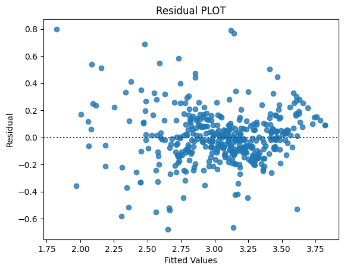

```python
fitted_val = model.fittedvalues

sns.residplot(x = fitted_val, y = residuals)

plt.xlabel("Fitted Values")

plt.ylabel("Residual")

plt.title("Residual PLOT")

plt.show()
```

#### Observations

- The linearity of variables is not evident, as the graph between the fitted values and the residual shows no real linear relationship. It is closer to a triangular shape that narrows at higher fitted values.

### Normality of error terms

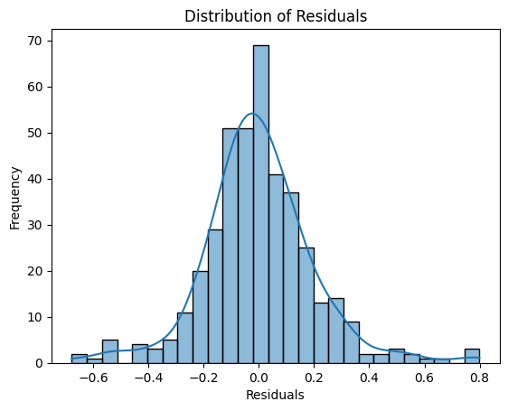

```python
# Histogram of Residuals
sns.histplot(residuals, kde=True)
plt.title('Distribution of Residuals')
plt.xlabel('Residuals')
plt.ylabel('Frequency')
plt.show()
```

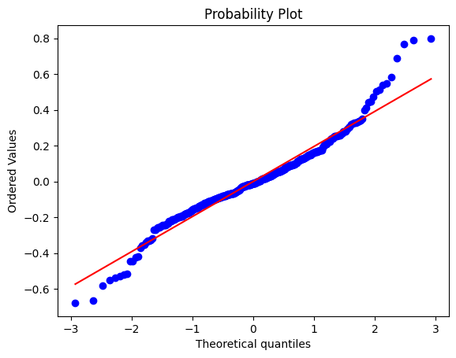

```python
import pylab
import scipy.stats as stats

# Making a probability plot to look at the distribution across quantities
stats.probplot(residuals, dist = "norm", plot = pylab)
plt.show()
```

#### Observations

- The residuals are both evenly distributed and fall within the linear relationship expected, although the extreme values (close to either -3 or 3) tend to be a lot further away from the expected, which could be a sign that some outlier values are heavily impacting the data set.

```python
new_indep_test = independent_test.drop(['TAX', 'NOX'], axis = 1)
```

```python
# Creating prediction
y_pred_train = model.predict(independent_train)
y_observed_train = dependent_train

# Predicting on test data
y_pred_test = model.predict(new_indep_test)
y_observed_test = dependent_test
```

```python
r_squared = r2_score(y_observed_train, y_pred_train)
rmse = mean_squared_error(y_observed_train, y_pred_train, squared=False)
mae = mean_absolute_error(y_observed_train, y_pred_train)
mape = np.mean(np.abs((y_observed_train - y_pred_train) / y_observed_train)) * 100

print(f"R-squared: {r_squared}")
print(f"RMSE: {rmse}")
print(f"MAE: {mae}")
print(f"MAPE: {mape}")
```

```
R-squared: 0.765280398446433
RMSE: 0.19912934299879417
MAE: 0.142961718181372
MAPE: 4.974022349155312
```

```python
r_squared = r2_score(y_observed_test, y_pred_test)
rmse = mean_squared_error(y_observed_test, y_pred_test, squared=False)
mae = mean_absolute_error(y_observed_test, y_pred_test)
mape = np.mean(np.abs((y_observed_test - y_pred_test) / y_observed_test)) * 100

print(f"R-squared: {r_squared}")
print(f"RMSE: {rmse}")
print(f"MAE: {mae}")
print(f"MAPE: {mape}")
```

```
R-squared: 0.7333624506634199
RMSE: 0.20387369514944495
MAE: 0.1335296637951329
MAPE: 4.736804929065331
```

## Final Model

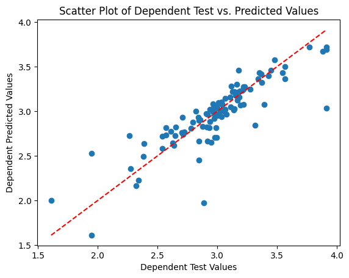

```python
predictions = model.predict(new_indep_test)
plt.scatter(dependent_test, predictions)
plt.xlabel("Dependent Test Values")
plt.ylabel("Dependent Predicted Values")
plt.title("Scatter Plot of Dependent Test vs. Predicted Values")

x = np.linspace(min(dependent_test), max(dependent_test), 100)
y = x
plt.plot(x, y, color='red', linestyle='--')

plt.show()
```

### Observations

- By plotting the originally created model and comparing it to the predicted values, as well as using the dashed red line that acts as a guide of how the values should be distributed in the graph, we can see that we get a generally appropriate relationship between the dependent values using in the testing of the model and what the model predicted.

## Actionable Insights and Recommendations

**Recommendations:**

- Further tuning done in model, as well as testing relationships other than linear regression, such as Ridge/Lasso Regression or Decision Trees, is needed in order to fin the truly best option for this project. Although linear regression does show a good relationship and the R-squared and RMSE have good values, they could be better, and other models could fit the data better as well.
- The housing market rapidly changes nowadays, especially with the increasingly higher prices present in cities. The model might need to be retrained somewhat frequently to account for the rapid growth of certain cities (like recently Dallas, Texas) or the preferences of renting over purchasing.
- Similarly, this is just a general database of prices and its economic factors like Taxes or intrinsic details of the home like its Age. This leaves out other factors surrounding the home, such as if it was remodeled, if it is in a large city, etc. that heavily impact house pricing.
- Certain markets, like California or New York, might have extremely expensive outliers that do not follow the same relationship as the general market, while some poor, rural areas with really bad housing markets might suffer from similar issues, so if a general model that will be applied to everything is created, it should be done with discretion as it might miss those nuances.